# pipeComp evaluation

Won-Min Song

2024-12-13

#### Comparative analysis of MSC and other benchmark clustering methods

This is the R script used to perform comparative analysis of MSC with other benchmark methods with pipeComp data sets. These data sets have gold-standard ground-truth clusters, and the raw count matrix and pre-processed data by Seurat workflow can be downloaded from Synpase with DOI, https://doi.org/10.7303/syn52966803, under ‘pipeComp’ folder.

[Section 1. pipeComp data pre-processing](http://localhost:8787/file_show?path=%2Ftmp%2FRtmp1BZpvj%2Fpreview-23f6162e61c6.dir%2FpipeComp_workflow.html#S1): The ‘Data’ subfolder contains the raw count matrices in .RDS format, and the pre-processed data is in ‘quality_controlled_seurat.results.RDS’ in the main folder in .RDS format, a gzipped format of R objects. Placing ‘quality_controlled_seurat.results.RDS’ in the working folder will bypass [Section 1](http://localhost:8787/file_show?path=%2Ftmp%2FRtmp1BZpvj%2Fpreview-23f6162e61c6.dir%2FpipeComp_workflow.html#S1).;  
[Section 2. Calculate clusters using benchmark methods](http://localhost:8787/file_show?path=%2Ftmp%2FRtmp1BZpvj%2Fpreview-23f6162e61c6.dir%2FpipeComp_workflow.html#S2): The main folder contains .RDS files to hold results for individual benchmark methods. Placing “single_layer_cluster_results.RDS” in the working folder will bypass this section.;  
[Section 3. Calculate clusters using MSC](http://localhost:8787/file_show?path=%2Ftmp%2FRtmp1BZpvj%2Fpreview-23f6162e61c6.dir%2FpipeComp_workflow.html#S3): The main folder contains .RDS files to hold MSC results from Pearson’s correlation (iterative_MSC.correlation.results.RDS) and Euclidean distance (iterative_MSC.euclidean.results.RDS). Also, this section will generate results from the single-layer split by AdaptSplit without performing the iterative top-down approach. The discrete clustering results from the ADaptSplit can also be obtained from the Synapse repository (Pearson’s correlation-based results: adaptsplit.correlation.results.RDS, Euclidean distance-based results: adaptsplit.euclidean.results.RDS). ;  
[Section 4. Comparative evaluation of discrete partitions using adjusted Rand Index](http://localhost:8787/file_show?path=%2Ftmp%2FRtmp1BZpvj%2Fpreview-23f6162e61c6.dir%2FpipeComp_workflow.html#S4): This section reproduces the figures to calculate the adjusted Rand Index on single-layer clustering results including CIDR, SC3, SNN-based Louvain clustering and AdaptSplit;  
[Section 5. Comparative evaluation of iterative top-down clustering results](http://localhost:8787/file_show?path=%2Ftmp%2FRtmp1BZpvj%2Fpreview-23f6162e61c6.dir%2FpipeComp_workflow.html#S5): This section reproduces the figures to calculate inclusion, coverage rates and detection accuracy for performance metrics in the gold standard clusters.;

## Section 1. pipeComp data pre-processing

```r
rm(list = ls())

library(Seurat)
library(scater)
library(scran)
library(cowplot)
library(CIDER)
library(cidr)
library(mclust)
library(MSC)
library(Matrix)
library(doParallel)
library(igraph)
library(SC3)

#### Set up folders
root.dir <- "/home/won-min/Documents/R_packages/Single_Cell_Clustering/pipeComp_v3";setwd(root.dir)

min.size = 5 # minimum cell cluster size
n.cores = 6 # number of cores to use

run.preprocess = FALSE # set this FALSE if 'quality_controlled_seurat.results.RDS' is already downloaded in the working folder.
run.clustering = FALSE # set FALSE if want to bypass the clustering process.

#### load pipeComp data collection and use Seurat workflow for pre-processing.
if (run.preprocess)
{
  #############
  simfiles <- list.files(path = "pipeComp/Data",full.names = TRUE)
  names(simfiles) = gsub("^(.*)/|\\.SCE\\.rds","",simfiles)
  seu.list = vector("list",length(simfiles));names(seu.list) = names(simfiles)
  for (i in 1:length(simfiles))
  {
    sce= readRDS(file = simfiles[i])
    seu = CreateSeuratObject(counts = counts(sce),meta.data = as.data.frame(colData(sce)))
    if (any(colnames(seu@meta.data) == "pldf.class"))
    {
      seu = subset(seu,pldf.class == "singlet" & pct_counts_Mt <= 20 & total_features >= 100)
    }else{
      seu = subset(seu,pct_counts_Mt <= 20 & total_features >= 100)
    }
    seu <- NormalizeData(seu)
    #seu <- FindVariableFeatures(seu, selection.method = "vst", nfeatures = 3000)
    seu <- ScaleData(seu)
    VariableFeatures(seu) = rownames(subset(qc.results[[i]]$gene.data,bio > tech & p.value < 0.05))
    seu = RunPCA(seu,npcs = 20)
    seu.list[[i]] = seu;
    rm(seu)
  }

  saveRDS(seu.list,file = "quality_controlled_seurat.results.RDS")
}else{
  seu.list = readRDS("quality_controlled_seurat.results.RDS")
}
```

## Section 2. Calculate clusters using benchmark methods

```r
##### Create functions for generating the benchmark clusters
if (run.clustering)
{
  # get SNN-based clusters at different resolutions: 0.4,0.8 and 1.2
  get_snn_clusters <- function(seu,resol.vec = seq(0.4,1.2,0.4))
  {
    seu <- FindNeighbors(seu)
    seu <- FindClusters(seu, resolution = resol.vec)
    seu.cls.col = colnames(seu@meta.data)[grep("snn_res",colnames(seu@meta.data))]

    snn.data = seu@meta.data[,seu.cls.col]
    rownames(snn.data) = colnames(seu)
    colnames(snn.data) = gsub("^(.*)_snn_res","seurat_snn_res",colnames(snn.data))
    snn.mods = lapply(snn.data,function(x) split(rownames(snn.data),factor(x)))

    for (i in 1:length(seu.cls.col))
    {
      names(snn.mods[[i]]) = paste0(names(snn.mods)[i],"_C",names(snn.mods[[i]]))
    }
    names(snn.mods) = NULL
    snn.mods = do.call('c',snn.mods)

    output = list(modules = snn.mods,cluster.matrix = snn.data)

    return(output)
  }
  # get CIDR results
  run_cidr <- function(tags)
  {
    require(cidr)
    #grp = unique(sce$phenoid)
    #cmap = rainbow(length(grp));names(cmap)=grp
    #cols = cmap[sce$phenoid];
    sData <- scDataConstructor(tags)
    sData <- determineDropoutCandidates(sData)
    sData <- wThreshold(sData)
    sData <- scDissim(sData)
    sData <- scPCA(sData)

    sData <- nPC(sData)
    nCluster(sData)

    sData <- scCluster(sData)

    return(sData)
  }
  # run SC3
  run_benchmark_clusters <- function(seu,n.cores = 4,dimred = "pca",dims = 1:10,sc3.seed = 1234)
  {

    ## SC3
    library(SC3)
    sce = as.SingleCellExperiment(seu)
    rowData(sce)$feature_symbol = rownames(sce)
    counts(sce) = as.matrix(counts(sce))
    logcounts(sce) = as.matrix(logcounts(sce))
    set.seed(sc3.seed)
    sce = sc3(object = sce,k_estimator = TRUE,biology = FALSE,n_cores = n.cores)

    seu@meta.data$SC3_clusters = colData(sce)[[grep("^sc3_",colnames(colData(sce)))]]

    return(seu)
  }

  # load pre-processed file if section 1 wasn't run
  if (!any(ls() == "seu.list")) seu.list = readRDS("quality_controlled_seurat.results.RDS")

  #### run analysis: SNN-based Louvain, SC3 and CIDR
  snn.results = sc3.lst = cidr.lst = vector("list",length(seu.list));
  names(snn.results) = names(sc3.lst) = names(cidr.lst) = names(seu.list)
  for (i in 1:length(simfiles))
  {
    seu = seu.list[[i]]
    nc = min(c(20,ncol(Embeddings(seu,"pca"))))

    # run SNN-based Louvain clustering
    snn.results[[i]] = get_snn_clusters(seu,resol.vec = c(0.4,0.8,1.2))

    # SC3 clustering
    bench.out = run_benchmark_clusters(seu,n.cores = n.cores,dimred = "pca",dims = 1:nc,sc3.seed = 1234)
    vec = bench.out@meta.data$SC3_clusters;names(vec) = colnames(seu)
    sc3.lst[[i]] = vec;
    rm(vec)


    #### add cidr results
    cidr.obj = run_cidr(tags = as.matrix(GetAssayData(seu,layer = "counts")))
    cidr.res = factor(cidr.obj@clusters);names(cidr.res) = colnames(seu)
    cidr.lst[[i]] = cidr.res
    rm(bench.out,seu,cidr.obj,cidr.res)
  }
}
```

## Section 3. Calculate clusters using MSC

```r
if (run.clustering)
{
  # load pre-processed file if section 1 wasn't run
  if (!any(ls() == "seu.list")) seu.list = readRDS("quality_controlled_seurat.results.RDS")

  #### run analysis: MSC-Euclidean. Will get full clustering as well as AdaptSplit results in Euclidean metrics.
  lena.euclid.results = split.euclid.results = vector("list",length(seu.list))
  names(lena.euclid.results) = names(split.euclid.results) = names(seu.list)

  for (i in 1:length(seu.list))
  {
    cat(paste0("processing:",names(seu.list)[i],"\n"))
    mat = as.matrix(t(Embeddings(seu.list[[i]],"pca")))
    if (T)
    {
      # get LEN
      len.out = generate_cell_network.wt.loess(
        mat,
        bcnt = NULL,
        dist.func = function(x,y) sqrt(sum((x-y)^2)),
        is.decreasing = FALSE,
        n.cores = 4
      );


      # run MSC
      d.func = function(x) x

      cout = components(len.out)
      ci = which(cout$csize > log(vcount(len.out)))
      glst = lapply(ci,function(n) induced_subgraph(graph = len.out,vids = names(cout$membership)[cout$membership == n]))
      alpha.res = sapply(glst,function(gi) identify_scale_parameter(g = gi,nv = 20,nr.max = 3,seed = 1234,d.func = d.func,mode = "diameter"))[1]
      gc()

      iter.res = iterative_clustering(g.in = len.out,min.size = 5,d.func = d.func,alpha = alpha.res)

      lena.euclid.results[[i]] = iter.res

    }


    ### get adapt split results
    # find root
    gh = graph.data.frame(iter.res$module.table[,c("parent.cluster","cluster.name")],directed = T)
    deg = igraph::degree(gh,mode = "in");rid = names(deg)[deg == 0];
    pid = sapply(iter.res$modules,length)[rid];pid = names(pid)[which.max(pid)]
    vec = get_rooted_membership(mtbl = iter.res$module.table,modules = iter.res$modules,pid = pid,bg = colnames(mat))
    split.euclid.results[[i]] = vec
    rm(cout,cu,glst,alpha.res,iter.res,len.out)
  }

  #### run analysis: MSC-Pearson. Will get full clustering as well as AdaptSplit results in Pearson correlation.
  lena.cor.results = split.cor.results = vector("list",length(qc.results))
  names(lena.cor.results) = names(split.cor.results) = names(qc.results)
  for (i in 1:length(seu.list))
  {
    cat(paste0("processing:",names(seu.list)[i],"\n"))

    ### run MSC clustering
    # for imputed data for correlation computation
    feats = rownames(subset(qc.results[[i]]$gene.data,bio > tech & p.value < 0.05))
    cat(paste0("- #. features:",length(feats),"\n"))
    dat = GetAssayData(seu.list[[i]],layer = "data")
    dat = dat[feats,]
    bcnt = GetAssayData(seu.list[[i]],layer = "counts")
    bcnt = bcnt[rownames(dat),]

    # get LEN
    len.out = generate_cell_network.wt.loess(
      mat = dat,
      bcnt = bcnt,
      dist.func = function(a, b) cor(a,b,method ="pearson"),
      is.decreasing = TRUE,
      n.cores = 4
    );

    # run MSC
    d.func = function(x) sqrt(2*(1-x))

    cout = components(len.out)
    ci = which(cout$csize > log(vcount(len.out)))
    glst = lapply(ci,function(n) induced_subgraph(graph = len.out,vids = names(cout$membership)[cout$membership == n]))

    alpha.res = sapply(glst,function(gi) identify_scale_parameter(g = gi,nv = 20,nr.max = 3,seed = 1234,d.func = d.func,mode = "diameter"))[1]
    gc()

    iter.res = iterative_clustering(g.in = len.out,min.size = 5,d.func = d.func,alpha = alpha.res)

    lena.cor.results[[i]] = iter.res

    ### get adapt split results
    # find root
    gh = graph.data.frame(iter.res$module.table[,c("parent.cluster","cluster.name")],directed = T)
    deg = igraph::degree(gh,mode = "in");rid = names(deg)[deg == 0];
    pid = sapply(iter.res$modules,length)[rid];pid = names(pid)[which.max(pid)]
    vec = get_rooted_membership(mtbl = iter.res$module.table,modules = iter.res$modules,pid = pid,bg = colnames(seu.list[[i]]))
    split.cor.results[[i]] = vec
    rm(cout,cu,glst,alpha.res,iter.res,len.out)
  }

  # put results into a single matrix per data set for single-layer clusters
  clus.results.layer = vector("list",length(seu.list));names(clus.results.layer) = names(seu.list)
  for (i in 1:length(seu.list))
  {
    snn.res = snn.results[[i]]$cluster.matrix
    clus.data = data.frame(cell.id = seu.list[[i]]@meta.data$orig.ident,phenoid = seu.list[[i]]@meta.data$phenoid,
                           as.data.frame(snn.res[match(colnames(seu.list[[i]]),rownames(snn.res)),]))
    clus.data$SC3 = sc3.lst[[i]][colnames(seu.list[[i]])]
    clus.data$CIDR = cidr.lst[[i]][colnames(seu.list[[i]])]
    clus.data$AdaptSplit.Euclidean = split.euclid.results[[i]][colnames(seu.list[[i]])]
    clus.data$AdaptSplit.Correlation = split.cor.results[[i]][colnames(seu.list[[i]])]
    clus.results.layer[[i]] = clus.data;
    rm(clus.data)
  }

}
```

## Section 4. Comparative evaluation of discrete partitions using adjusted Rand Index

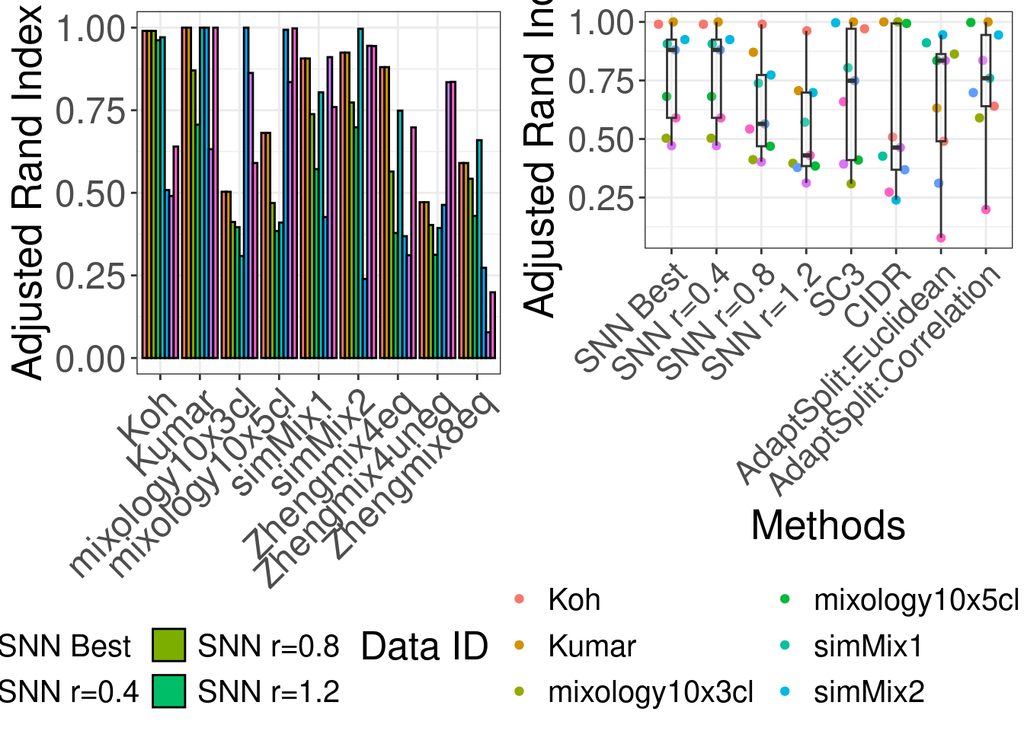

```r
setwd(root.dir)
# load inputs
if (!any(ls() == "seu.list")) seu.list = readRDS("quality_controlled_seurat.results.RDS")
if (!any(ls() == "clus.results.layer")) clus.results.layer = readRDS("single_layer_cluster_results.RDS")

# calculate adjusted rand index
adj.matrix = matrix(0,nrow = length(seu.list),ncol = 7)
rownames(adj.matrix) = names(seu.list)
for (i in 1:length(clus.results.layer))
{
  clus.res.f = clus.results.layer[[i]]
  adj.vec = sapply(clus.res.f[,grepl("snn|SC3|CIDR|AdaptSplit",colnames(clus.res.f))],function(x) adjustedRandIndex(x = clus.res.f$phenoid,y = x))
  adj.matrix[i,] = adj.vec
  if (i == 1) colnames(adj.matrix) = colnames(clus.res.f)[3:ncol(clus.res.f)]
}

# plot out results
adjr.matrix = adj.matrix
# rename methods for simpler names
colnames(adjr.matrix) = c("SNN r=0.4","SNN r=0.8","SNN r=1.2","SC3","CIDR","AdaptSplit:Euclidean","AdaptSplit:Correlation")
adjr.matrix = cbind(apply(adjr.matrix[,1:3],1,max),adjr.matrix)
colnames(adjr.matrix)[1] = "SNN Best"

library(ggbeeswarm)
library(reshape)
pdata = melt(adjr.matrix);colnames(pdata) = c("data.id","method","adjusted.rand")
levels(pdata$method)[levels(pdata$method) == "MSC:1st Split"] = "MSC:AdaptSplit"
pobj.1 = ggplot(data = pdata) +
  geom_bar(aes(x = data.id,y = adjusted.rand,,fill = method),stat = "identity",position = "dodge",colour = "black") + theme_bw() +
  labs(x = "Data ID",y = "Adjusted Rand Index") +
  guides(fill = guide_legend(title = "Method",ncol = 4),colour = "none") +
  theme(axis.text.x = element_text(size = 18,angle = 45,vjust = 1,hjust = 1),axis.text.y = element_text(size = 18),
        axis.title.y = element_text(size = 20),
        axis.title.x = element_blank(),
        legend.title = element_text(size = 19),legend.text = element_text(size = 15),
        plot.subtitle = element_text(size = 27,face = "bold",hjust = -0.05),
        legend.position = "bottom")

pobj.2 = ggplot() + geom_quasirandom(data = pdata,aes(x = method,y = adjusted.rand,colour = data.id)) +
  labs(x = "Methods",y = "Adjusted Rand Index") +
  guides(colour = guide_legend(title = "Data ID",ncol = 3)) +
  geom_boxplot(data = pdata,aes(x = method,y = adjusted.rand),width = 0.2,alpha = 0.2) + theme_bw() +
  theme(axis.text.x = element_text(size = 16,angle = 45,vjust = 1,hjust = 1),axis.text.y = element_text(size = 17),
        axis.title = element_text(size = 20),legend.title = element_text(size = 19),legend.text = element_text(size = 15),
        plot.subtitle = element_text(size = 27,face = "bold",hjust = -0.05),
        legend.position = "bottom")

library(cowplot)
print(plot_grid(pobj.1,pobj.2))
```

## Section 5. Comparative evaluation of iterative top-down clustering results

[output not shown]

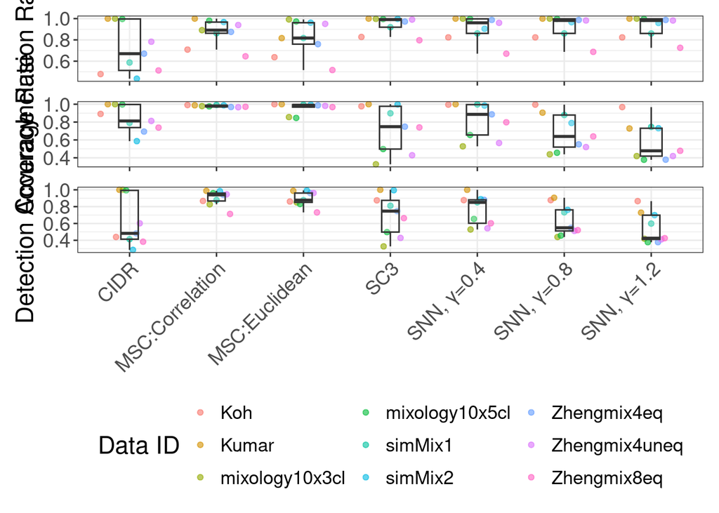